# Weekly Exercises #6

## Webscraping exercise (also from tutorial)

Use the data from the [Macalester Registrar’s Fall 2017 Class Schedule](https://www.macalester.edu/registrar/schedules/2017fall/class-schedule/#crs10008) to complete all these exercises.

6. Find the correct selectors for the following fields. Make sure that each matches 762 results:
- Course Number
- Course Name
- Day
- Time
- Room
- Instructor
- Avail. / Max
- General Education Requirements (make sure you only match 762; beware of the Mac copyright banner at the bottom of the page!)
- Description

Then, put all this information into one dataset (tibble or data.frame) Do not include any extraneous information like “Instructor:”.

```r
fall2017 <- (read_html(url("https://www.macalester.edu/registrar/schedules/2017fall/class-schedule")))

course_nums <-
  fall2017 %>%
  html_elements(".class-schedule-course-number") %>%
  html_text2()
head(course_nums)
```

```
## [1] "AMST 101-01" "AMST 103-01" "AMST 200-01" "AMST 203-01" "AMST 219-01"
## [6] "AMST 229-01"
```

```r
course_names <-
  fall2017 %>%
  html_elements(".class-schedule-course-title") %>%
  html_text2()
head(course_names)
```

```
## [1] "Explorations of Race and Racism"
## [2] "The Problems of Race in US Social Thought and Policy"
## [3] "Critical Methods for American Studies Research"
## [4] "Politics and Inequality: American Welfare State"
## [5] "In Motion: African Americans in the United States"
## [6] "Narrating Black Women's Resistance"
```

```r
course_days <-
  fall2017 %>%
  html_elements("td.class-schedule-label:nth-child(3)") %>%
  html_text2() %>%
  str_sub(start = 7)
head(course_days)
```

```
## [1] "W"   "MWF" "MWF" "MWF" "MWF" "MWF"
```

```r
course_time <-
  fall2017 %>%
  html_elements(".class-schedule-label:nth-child(4)") %>%
  html_text2() %>%
  str_sub(start = 7)
head(course_time)
```

```
## [1] "07:00 pm-10:00 pm" "09:40 am-10:40 am" "02:20 pm-03:20 pm"
## [4] "09:40 am-10:40 am" "01:10 pm-02:10 pm" "10:50 am-11:50 am"
```

```r
course_room <-
  fall2017 %>%
  html_elements(".class-schedule-label:nth-child(5)") %>%
  html_text2() %>%
  str_sub(start = 7)
head(course_room)
```

```
## [1] "ARTCOM 102" "NEILL 111"  "OLRI 205"   "CARN 204"   "MAIN 010"
## [6] "MAIN 001"
```

```r
course_instructor <-
  fall2017 %>%
  html_elements(".class-schedule-label:nth-child(6)") %>%
  html_text2() %>%
  str_sub(start = 13)
head(course_instructor)
```

```
## [1] "Gutierrez, Harris"      "Karin Aguilar-San Juan" "Nathan Titman"
## [4] "Lesley Lavery"          "Crystal Moten"          "Crystal Moten"
```

```r
course_seats <-
  fall2017 %>%
  html_elements(".class-schedule-label:nth-child(7) ") %>%
  html_text2() %>%
  str_sub(start = 14) %>%
  str_remove("Closed")
head(course_seats)
```

```
## [1] " -5 / 25" "0 / 16"   "13 / 20"  " 0 / 25"  "2 / 20"   " 4 / 14"
```

```r
course_gened <-
  fall2017 %>%
  html_elements("#content p:nth-child(2)") %>%
  html_text2() %>%
  str_sub(start = 35)
head(course_gened)
```

```
## [1] "U.S. Identities and Differences\n"
## [2] "U.S. Identities and Differences\nWriting WA\n"
## [3] ""
## [4] "U.S. Identities and Differences\nWriting WP\n"
## [5] "U.S. Identities and Differences\n"
## [6] ""
```

```r
course_desc <-
  fall2017 %>%
  html_elements(".collapsed p:nth-child(1)") %>%
  html_text2() %>%
  str_sub(start = 3)
head(course_desc)
```

```
## [1] "The main objectives of this introductory course are: to explore the historical construction of racial categories in the United States; to understand the systemic impact of racism on contemporary social processes; to consider popular views about race in the light of emerging scholarship in th…
## [2] "In this discussion-based and residential course, we will explore the paradox of a society in which people are increasingly aware of patterns of racism and yet still unable to see or explain how those systems and patterns are connected to everyday life. As awareness increases, why are we not …
## [3] "This course will introduce students to interdisciplinary research approaches to the study of race, ethnicity, and other categories of difference. Students will learn to conceptualize and design research projects, and will obtain hands-on experience in executing different methods. The course …
## [4] "Americans, at least since the Founding era, have cherished the ideal of political equality. Unlike European nations, the United States did not inherit economic class distinctions from a feudal past. But time and again, American social reformers and mass movements have highlighted inconsisten…
## [5] "In Motion is an introduction to modern African American History from slavery to contemporary times. In Motion emphasizes the idea that both African Americans and the stories of their lives in the United States are fluid, varied and continually being reinterpreted. Rather than a strict chrono…
## [6] "This course examines traditions of 20th century African American women’s activism and the ways in which they have changed over time. Too often, the narrative of the “strong black woman” infuses stories of African American women’s resistance which, coupled with a culture of dissemblance, make…
```

```r
course_df <- tibble(number=course_nums, name=course_names, days=course_days, time=course_time, room=course_room, instructor=course_instructor, seats=course_seats, general_reqs=course_gened, description=course_desc)
head(course_df)
```

| number | name | days | time | room | instructor | seats | general_reqs | description |
| --- | --- | --- | --- | --- | --- | --- | --- | --- |
| AMST 101-01 | Explorations of Race and Racism | W | 07:00 pm-10:00 pm | ARTCOM 102 | Gutierrez, Harris | -5 / 25 | U.S. Identities and Differences\n | The main objectives of this introductory course are: to explore the historical construction of racial categories in the United States; to understand the systemic impact of racism on contemporary socia… |
| AMST 103-01 | The Problems of Race in US Social Thought and Policy | MWF | 09:40 am-10:40 am | NEILL 111 | Karin Aguilar-San Juan | 0 / 16 | U.S. Identities and Differences\nWriting WA\n | In this discussion-based and residential course, we will explore the paradox of a society in which people are increasingly aware of patterns of racism and yet still unable to see or explain how those … |
| AMST 200-01 | Critical Methods for American Studies Research | MWF | 02:20 pm-03:20 pm | OLRI 205 | Nathan Titman | 13 / 20 |  | This course will introduce students to interdisciplinary research approaches to the study of race, ethnicity, and other categories of difference. Students will learn to conceptualize and design resear… |
| AMST 203-01 | Politics and Inequality: American Welfare State | MWF | 09:40 am-10:40 am | CARN 204 | Lesley Lavery | 0 / 25 | U.S. Identities and Differences\nWriting WP\n | Americans, at least since the Founding era, have cherished the ideal of political equality. Unlike European nations, the United States did not inherit economic class distinctions from a feudal past. B… |
| AMST 219-01 | In Motion: African Americans in the United States | MWF | 01:10 pm-02:10 pm | MAIN 010 | Crystal Moten | 2 / 20 | U.S. Identities and Differences\n | In Motion is an introduction to modern African American History from slavery to contemporary times. In Motion emphasizes the idea that both African Americans and the stories of their lives in the Unit… |
| AMST 229-01 | Narrating Black Women's Resistance | MWF | 10:50 am-11:50 am | MAIN 001 | Crystal Moten | 4 / 14 |  | This course examines traditions of 20th century African American women’s activism and the ways in which they have changed over time. Too often, the narrative of the “strong black woman” infuses storie… |

7. Create a graph that shows the number of sections offered per department. Hint: The department is a substring of the course number - there are `str_XXX()` functions that can help. Yes, COMP and MATH are the same department, but for this exercise you can just show the results by four letter department code, e.g., with COMP and MATH separate.

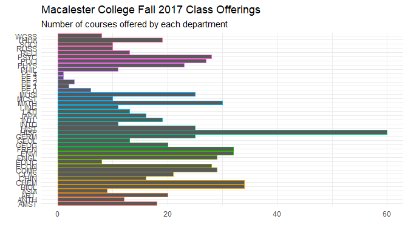

```r
course_df %>%
 mutate(department =  str_sub(number, start = 1, end = 4)) %>%
  group_by(department) %>%
  count(department) %>%
  ggplot(aes(x = n,
             y = department,
             color = department)) +
  geom_col() +
  labs(title = "Macalester College Fall 2017 Class Offerings",
       subtitle = "Number of courses offered by each department",
       y = "",
       x = "") +
  theme(legend.position = "FALSE")
```

8. Analyze the typical length of course names by department. To do so, create a new data table based on your courses data table, with the following changes:
- New columns for the length of the title of a course and the length of the description of the course. Hint: `str_length`.
- Remove departments that have fewer than 10 sections of courses. To do so, group by department, then remove observations in groups with fewer than 10 sections (Hint: use filter with n()). Then `ungroup()` the data.
- Create a visualization of the differences across groups in lengths of course names or course descriptions. Think carefully about the visualization you should be using!

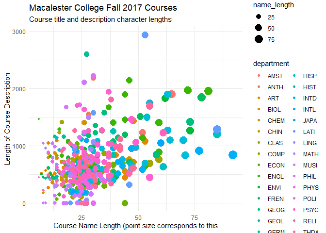

```r
long_course_df <- course_df %>%
  mutate(name_length = str_length(name),
         desc_length = str_length(description),
         department =  str_sub(number, start = 1, end = 4)) %>%
  group_by(department) %>%
  filter(n() > 10) %>%
  ungroup()

long_course_df %>%
  ggplot(aes(x = name_length, y = desc_length, color = department, size = name_length)) +
  geom_point() +
  labs(title = "Macalester College Fall 2017 Courses",
       subtitle = "Course title and description character lengths",
       y = "Length of Course Description",
       x = "Course Name Length (point size corresponds to this")
```

**DID YOU REMEMBER TO UNCOMMENT THE OPTIONS AT THE TOP?**